# portfolio 3

Jesper

7/11/2019

### lets load all the data:

```r
files <- list.files(path = "data",
                    pattern = ".csv",
                    full.names = T)

data <- lapply(files, read_csv) %>%
  plyr::rbind.fill()

data$Gender = as.factor(data$Gender)
data$Condition = as.factor(data$Condition)

database = read.csv("MRC_database.csv")

data$Word = toupper(data$Word)

# rename the capitalized column to "word"
colnames(data)[colnames(data) == "Word"] = "word"

merged = merge(data, database, by = "word")
```

### Now we have the data and merged it with the MRC_database. First lets look for outliers in the reaction time data since we will be making alot of correlational analysis on that continous varible

### As always outliers are defined as -3>z>3

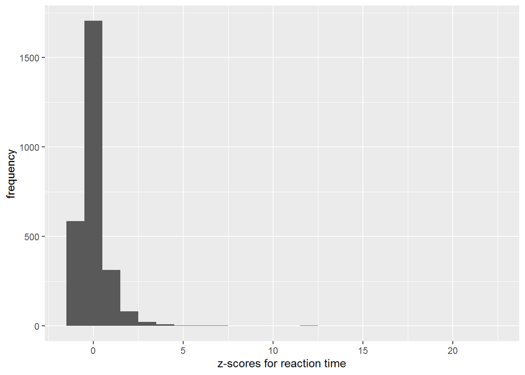

```r
merged$Reaction_timez = (merged$Reaction_time-mean(merged$Reaction_time))/(sd(merged$Reaction_time))

#removing z scores above 3, since there is no z-scores below -3. See plot below

merged1 = filter(merged, merged$Reaction_timez < 3)

ggplot(merged, aes(merged$Reaction_timez))+geom_histogram(binwidth = 1)+labs(y = "frequency", x = "z-scores for reaction time")
```

### Putting the z-score back to normal values.

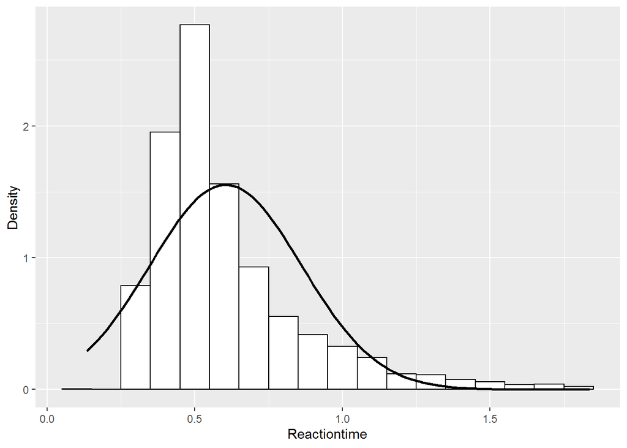

```r
merged1$Reaction_time2 = merged1$Reaction_timez*sd(merged$Reaction_time)+mean(merged$Reaction_time)

ggplot(merged1, aes(merged1$Reaction_time2)) + geom_histogram(aes(y=..density..), colour = "black", fill = "white", binwidth = 0.1) + labs(x ="Reactiontime", y = "Density") +
  stat_function(fun = dnorm, args = list(mean = mean(merged1$Reaction_time2), sd = sd(merged1$Reaction_time2)), colour= "black", size = 1)
```

## Part 1

### We now have to make a correlational analysis between Reactiontime and word number, word frequency in the MRC database and number of letters in a word.

#### Since all the varibles besides reaction time are ordinal, we wont be able to use pearsons correlational test because it assumes that both variables are continuous. Therefore we’ll be using either kendalls tau or spearsmans rho. One would choose kendalls tau over spearmans rho because it is more robust, and is better when there are alot of tied ranks, which we have in the ordinal data.

```r
cor.test(merged1$Reaction_time2, merged1$nlet, method = "kendall")
```

```
##
##  Kendall's rank correlation tau
##
## data:  merged1$Reaction_time2 and merged1$nlet
## z = 2.2828, p-value = 0.02244
## alternative hypothesis: true tau is not equal to 0
## sample estimates:
##        tau
## 0.03291127
```

#### Visualizing the correlation:

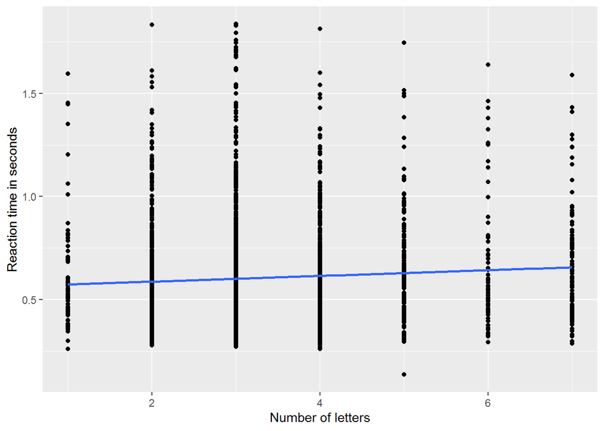

```r
ggplot(merged1, aes(merged1$nlet, merged1$Reaction_time2))+geom_point()+geom_smooth(method = "lm", se = FALSE)+labs(x = "Number of letters", y = "Reaction time in seconds")
```

### *Reactiontime was positivly correlated with number of letters in a word with a trivial effect size tau(2698) = 0.033 p < 0.05*

#### Lets compare reaction time to the freqency of that word’s occurrence in the MRC database.

```r
cor.test(merged1$Reaction_time2, merged1$kf_freq, method = "kendall")
```

```
##
##  Kendall's rank correlation tau
##
## data:  merged1$Reaction_time2 and merged1$kf_freq
## z = -4.3622, p-value = 1.288e-05
## alternative hypothesis: true tau is not equal to 0
## sample estimates:
##         tau
## -0.05759156
```

#### Again visualizing the correlation:

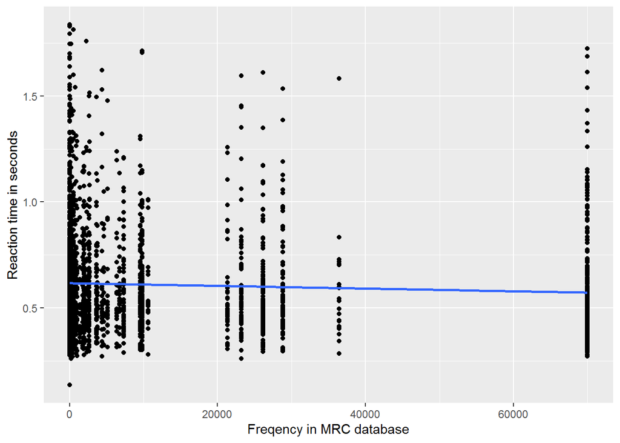

```r
ggplot(merged1, aes(merged1$kf_freq,
                  merged1$Reaction_time))+geom_point()+geom_smooth(method ="lm", se = FALSE)+labs(x = "Freqency in MRC database", y = "Reaction time in seconds")
```

### *Reactiontime was negativly correlated with word freqency in the MRC database with a trivial effect size tau(2698) = -0.058 p < 0.001*

#### Lastly comparing reaction-time to the word number.

```r
cor.test(merged1$Reaction_time2, merged1$X1, method = "kendall")
```

```
##
##  Kendall's rank correlation tau
##
## data:  merged1$Reaction_time2 and merged1$X1
## z = -4.1141, p-value = 3.887e-05
## alternative hypothesis: true tau is not equal to 0
## sample estimates:
##         tau
## -0.05308651
```

#### Visual representation:

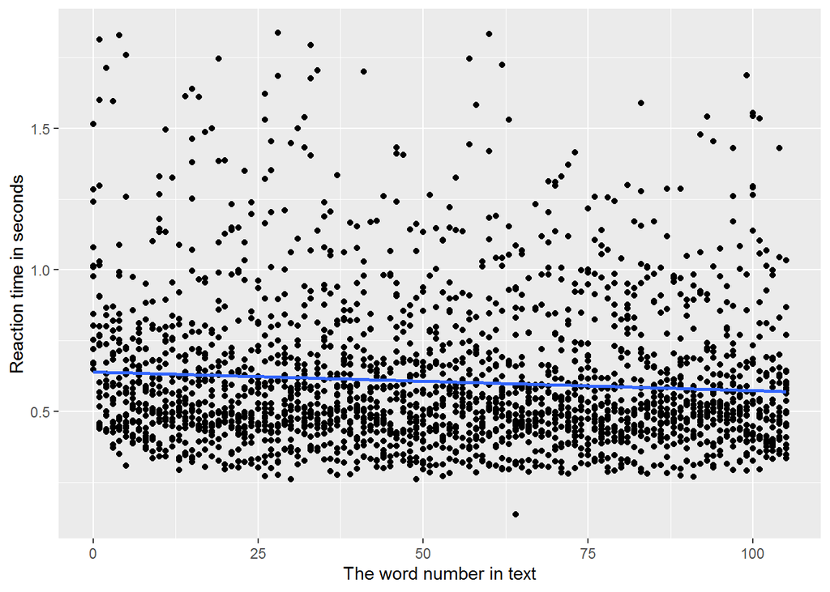

```r
ggplot(merged1, aes(merged1$X1, merged1$Reaction_time))+geom_point()+geom_smooth(method = "lm", se = FALSE)+labs(x = "The word number in text", y = "Reaction time in seconds")
```

### *Reactiontime was negativly correlated with word number with a trivial effect size tau(2698) = -0.053 p < 0.001*

## Part 2

### Since we have a independent design we’ll be using the independent t-test. Which means that in principle we won’t be needing to care about the assumption of homogenity of variance because R uses welchs t-test, which doesn’t assume homogenity of variance, however we’ll be looking at the homogenity of variance just for pratice.

#### First singling out word number 100(cow/ox) which is the salient word and then, the word after the salient word (word 101 (and))

```r
merged2 = filter(merged1, merged1$X1 == 100)
merged3 = filter(merged1, merged1$X1 == 101)
```

#### Before moving on we have to check wether the reactiontimes in the new dataframes are normally distrubuted. First we’ll check for reactiontime for word 100 (cow/ox). I found that the transformation 1/reaction time, gave the most normal data.

```r
con1 = filter(merged2, Condition == 1)
con2 = filter(merged2, Condition == 2)
```

#### Lets look at all the transformed reactiontime data. And see how it does in different tests for normality

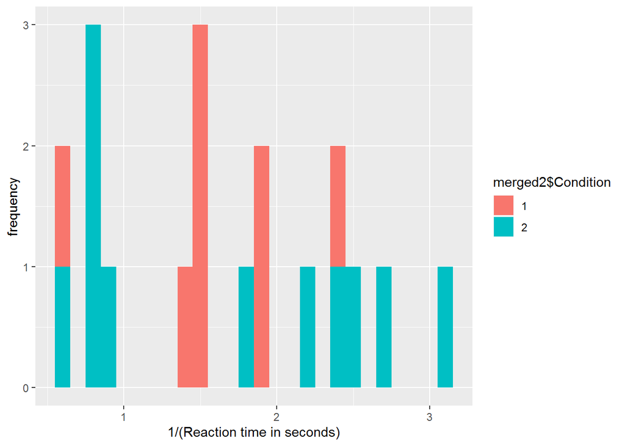

```r
ggplot(merged2, aes(1/(merged2$Reaction_time2), fill = merged2$Condition))+geom_histogram(binwidth = 0.1) + labs(x = "1/(Reaction time in seconds)", y = "frequency")
```

```r
stat.desc(1/(con1$Reaction_time2),  basic = FALSE, norm = TRUE)
```

```
##       median         mean      SE.mean CI.mean.0.95          var
##    1.4927043    1.5724551    0.1769246    0.4183601    0.2504184
##      std.dev     coef.var     skewness     skew.2SE     kurtosis
##    0.5004182    0.3182401   -0.2528865   -0.1681199   -0.6807932
##     kurt.2SE   normtest.W   normtest.p
##   -0.2298609    0.9392849    0.6040584
```

```r
stat.desc(1/(con2$Reaction_time2),  basic = FALSE, norm = TRUE)
```

```
##       median         mean      SE.mean CI.mean.0.95          var
##   1.77303052   1.68954921   0.28124998   0.62666401   0.87011707
##      std.dev     coef.var     skewness     skew.2SE     kurtosis
##   0.93280066   0.55210032   0.10112869   0.07653292  -1.88647387
##     kurt.2SE   normtest.W   normtest.p
##  -0.73724034   0.85189362   0.04517437
```

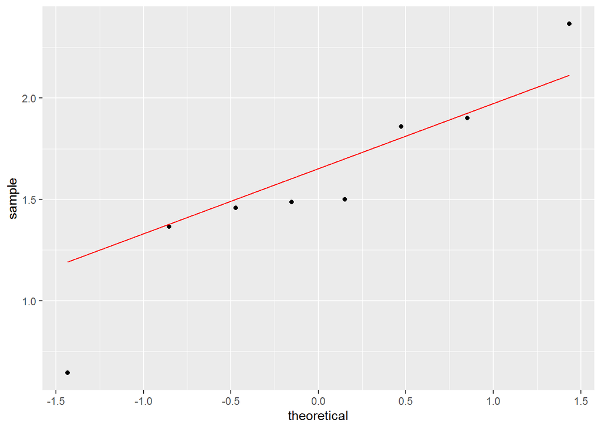

```r
ggplot(con1, aes(sample = 1/(con1$Reaction_time2)))+stat_qq()+stat_qq_line(colour = "red")
```

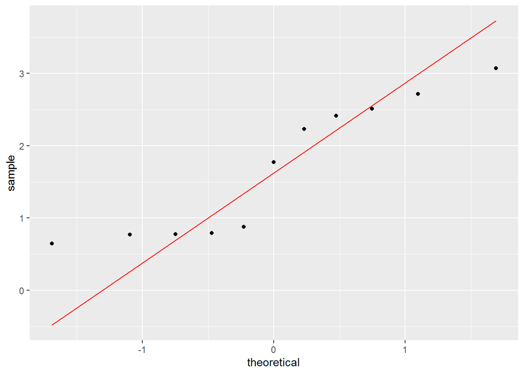

```r
ggplot(con2, aes(sample = 1/(con2$Reaction_time2)))+stat_qq()+stat_qq_line(colour = "red")
```

#### Firstly we see that reaction time in condition 1 for word 100 (ox) is kind of normally distrubuted shaprio-wilks test p > 0.05. kurt.2SE and skew.2SE are also above -1 and below 1. Furthere more the qq-plot looks okay.

#### We can now see that reaction time in condition 2 for word 100 (cow) is not really normally distrubuted, its significantly different for a perfect normal distrubution (shaprio-wilks test p < 0.05), it is however close to being non significant p = 0.045. It is inside the range of 1 and -1 for kurt.2SE and skew.2SE. However from the qq-plot i would say that the data is not normal, which means we’ll have to use a more robust t-test (yuen)

#### Since the assumption of normality is violated we won’t be needing to check wether the assumption of homogenity of variance is violated, because the robust t-test (yuen) does not assume that.

### T-test for the salient word.

```r
test1 = yuen(merged2$Reaction_time2 ~ merged2$Condition)

test1
```

```
## Call:
## yuen(formula = merged2$Reaction_time2 ~ merged2$Condition)
##
## Test statistic: 0.703 (df = 6.51), p-value = 0.50641
##
## Trimmed mean difference:  -0.15121
## 95 percent confidence interval:
## -0.6677     0.3652
##
## Explanatory measure of effect size: 0.24
```

```r
t1 = test1$test
df1 = test1$df
```

### Calculating the effect size

```r
r1 = sqrt(t1^2/(t1^2+df1))

r1
```

```
## [1] 0.265565
```

### Lets visualize it using a bar plot first for salient word (ox/cow)

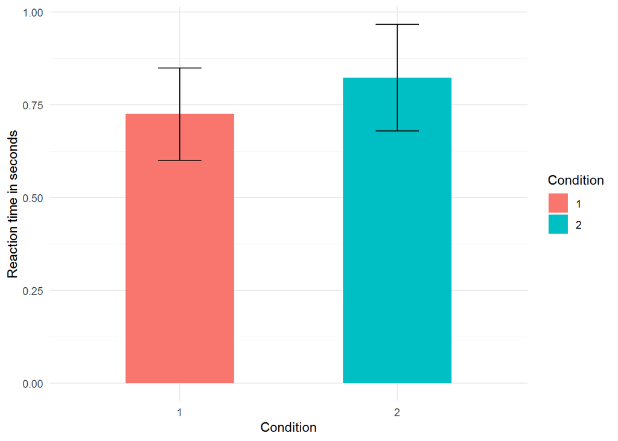

```r
ggplot(merged2, aes(x=merged2$Condition, y = merged2$Reaction_time2, fill = Condition))+
  geom_bar(stat='summary', fun.y = mean, width = 0.5)+
  geom_errorbar(stat = 'summary', fun.data = mean_se, width = 0.2)+
  labs(x = "Condition", y = "Reaction time in seconds")+theme_minimal()
```

### *The were no significant difference in the salient word (which were either cow or ox) and reactiontime in the two conditions: t(6.51) = -0.7 p > 0.05 r = 0.27*

### Now we have to do everything again but for word 101 (which is “and” in both conditions). Again the best transformation was to take the reciprocal value of reaction time.

```r
con11 = filter(merged3, Condition == 1)
con22 = filter(merged3, Condition == 2)
```

[figure not shown]

```r
ggplot(merged2, aes(1/(merged2$Reaction_time2), fill = merged2$Condition))+geom_histogram(binwidth = 0.1)
```

```r
stat.desc(1/(con11$Reaction_time2),  basic = FALSE, norm = TRUE)
```

```
##       median         mean      SE.mean CI.mean.0.95          var
##   1.63922119   1.63979831   0.18675016   0.43064664   0.31388060
##      std.dev     coef.var     skewness     skew.2SE     kurtosis
##   0.56025048   0.34165816  -0.03107020  -0.02166266  -1.69016126
##     kurt.2SE   normtest.W   normtest.p
##  -0.60375476   0.93582674   0.53871841
```

```r
stat.desc(1/(con22$Reaction_time2),  basic = FALSE, norm = TRUE)
```

```
##       median         mean      SE.mean CI.mean.0.95          var
##   2.07383990   2.03662894   0.19491876   0.42469150   0.49391320
##      std.dev     coef.var     skewness     skew.2SE     kurtosis
##   0.70278959   0.34507493  -0.10755265  -0.08725163  -0.43782731
##     kurt.2SE   normtest.W   normtest.p
##  -0.18382598   0.96116724   0.77158376
```

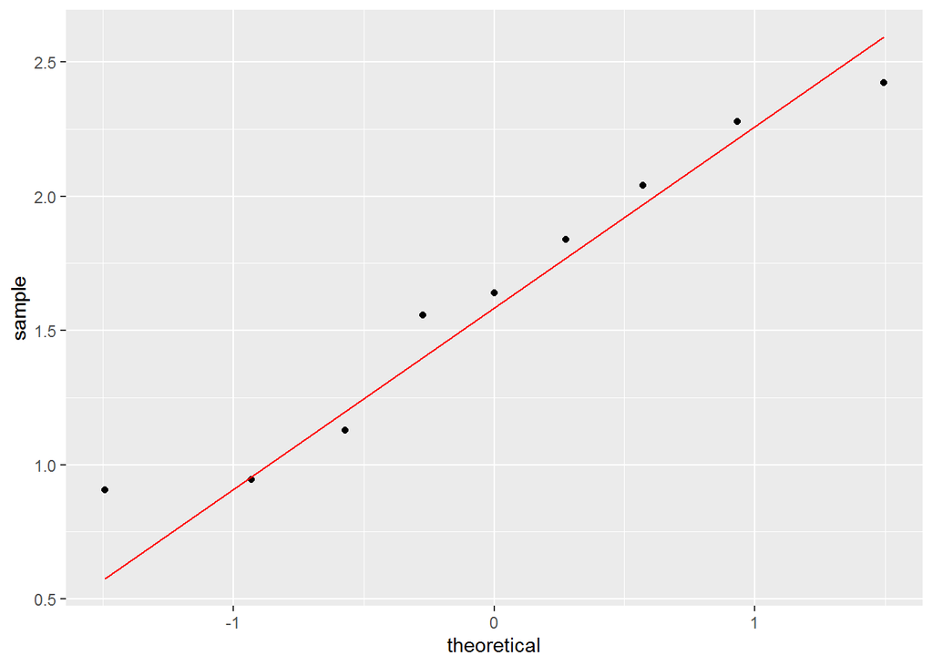

```r
ggplot(con11, aes(sample = 1/(con11$Reaction_time2)))+stat_qq()+stat_qq_line(colour = "red")
```

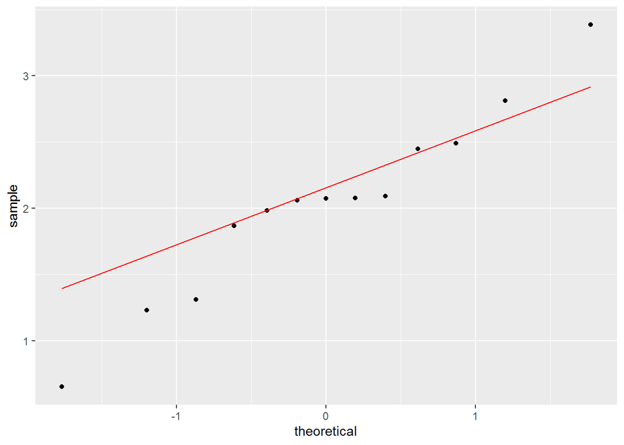

```r
ggplot(con22, aes(sample = 1/(con22$Reaction_time2)))+stat_qq()+stat_qq_line(colour = "red")
```

### Reaction times in both groups seem to be normally distrubuted they are not significantly different from a perfect normal distrubution and skew.2SE and kurt.2SE are both between -1 and 1. The qq-plot is also pretty good. The data-points closely resemble the line.

### Next is the check for homogenity of variance

```r
leveneTest(1/(merged3$Reaction_time2), merged3$Condition)
```

```
## Levene's Test for Homogeneity of Variance (center = median)
##       Df F value Pr(>F)
## group  1  0.0218 0.8842
##       20
```

#### The variance for reaction time for word 101 (and) was similiar between condition 1 and 2 F(1,20) = 0.02 p > 0.05.

### Finally making the last t-test:

```r
test2 = t.test(1/(merged3$Reaction_time2) ~ merged3$Condition)

t2 = test2$statistic[[1]]
df2 = test2$parameter[[1]]

test2
```

```
##
##  Welch Two Sample t-test
##
## data:  1/(merged3$Reaction_time2) by merged3$Condition
## t = -1.4701, df = 19.498, p-value = 0.1575
## alternative hypothesis: true difference in means is not equal to 0
## 95 percent confidence interval:
##  -0.9608516  0.1671904
## sample estimates:
## mean in group 1 mean in group 2
##        1.639798        2.036629
```

### Calculating the effect size

```r
#calculating the effect size for each of the differences
r2 = sqrt(t2^2/(t2^2+df2))

r2
```

```
## [1] 0.3158742
```

### Lets again visualize the results:

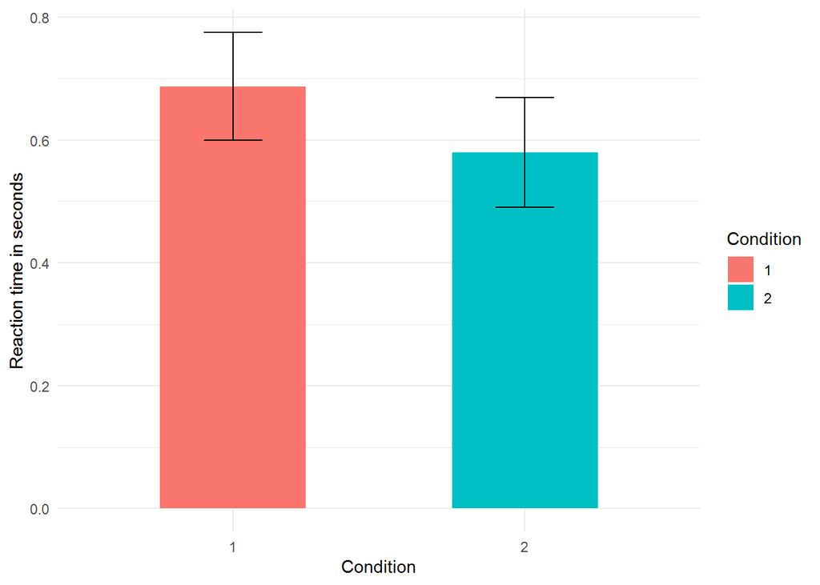

```r
ggplot(merged3, aes(x = merged3$Condition, y = merged3$Reaction_time2, fill = Condition))+
  geom_bar(stat='summary', fun.y = mean, width = 0.5)+
  geom_errorbar(stat = 'summary', fun.data = mean_se, width = 0.2)+
  labs(x = "Condition", y = "Reaction time in seconds")+theme_minimal()
```

### *There were no significant difference between the word after the salient word (which is “and”) and reactiontime in the two conditions:*

### *t(19.498) = -1.5 p > 0.05 r = 0.32*